# Investigate a Dataset - [tmdb-movies]

- Introduction
- Data Wrangling
- Exploratory Data Analysis
- Conclusions

## Introduction

```python
# Use this cell to set up import statements for all of the packages that you
#   plan to use.

# While optional for current notebooks, if you are having trouble with visualizations,
#   remember to include a 'magic word' so that your visualizations are plotted
#   inline with the notebook. See this page for more:
#   http://ipython.readthedocs.io/en/stable/interactive/magics.html

import pandas as pd
import numpy as np
import operator
import seaborn as sb
import matplotlib.pyplot as mpl
%matplotlib inline
```

## Data Wrangling

```python
# Load your data and print out a few lines. What is the size of your dataframe?
#   Perform operations to inspect data types and look for instances of missing
#   or possibly errant data. There are at least 4 - 6 methods you can call on your
#   dataframe to obtain this information.

# Read the CSV file into a Pandas DataFrame
df = pd.read_csv('tmdb-movies.csv')
# Display the first few rows of the DataFrame
df.head()
```

|  | id | imdb_id | popularity | budget | revenue | original_title | cast | homepage | director | tagline | ... | overview | runtime | genres | production_companies | release_date | vote_count | vote_average | release_year | budget_adj | revenue_adj |
| --- | --- | --- | --- | --- | --- | --- | --- | --- | --- | --- | --- | --- | --- | --- | --- | --- | --- | --- | --- | --- | --- |
| 0 | 135397 | tt0369610 | 32.985763 | 150000000 | 1513528810 | Jurassic World | Chris Pratt\|Bryce Dallas Howard\|Irrfan Khan\|Vi... | http://www.jurassicworld.com/ | Colin Trevorrow | The park is open. | ... | Twenty-two years after the events of Jurassic ... | 124 | Action\|Adventure\|Science Fiction\|Thriller | Universal Studios\|Amblin Entertainment\|Legenda... | 6/9/15 | 5562 | 6.5 | 2015 | 1.379999e+08 | 1.392446e+09 |
| 1 | 76341 | tt1392190 | 28.419936 | 150000000 | 378436354 | Mad Max: Fury Road | Tom Hardy\|Charlize Theron\|Hugh Keays-Byrne\|Nic... | http://www.madmaxmovie.com/ | George Miller | What a Lovely Day. | ... | An apocalyptic story set in the furthest reach... | 120 | Action\|Adventure\|Science Fiction\|Thriller | Village Roadshow Pictures\|Kennedy Miller Produ... | 5/13/15 | 6185 | 7.1 | 2015 | 1.379999e+08 | 3.481613e+08 |
| 2 | 262500 | tt2908446 | 13.112507 | 110000000 | 295238201 | Insurgent | Shailene Woodley\|Theo James\|Kate Winslet\|Ansel... | http://www.thedivergentseries.movie/#insurgent | Robert Schwentke | One Choice Can Destroy You | ... | Beatrice Prior must confront her inner demons ... | 119 | Adventure\|Science Fiction\|Thriller | Summit Entertainment\|Mandeville Films\|Red Wago... | 3/18/15 | 2480 | 6.3 | 2015 | 1.012000e+08 | 2.716190e+08 |
| 3 | 140607 | tt2488496 | 11.173104 | 200000000 | 2068178225 | Star Wars: The Force Awakens | Harrison Ford\|Mark Hamill\|Carrie Fisher\|Adam D... | http://www.starwars.com/films/star-wars-episod... | J.J. Abrams | Every generation has a story. | ... | Thirty years after defeating the Galactic Empi... | 136 | Action\|Adventure\|Science Fiction\|Fantasy | Lucasfilm\|Truenorth Productions\|Bad Robot | 12/15/15 | 5292 | 7.5 | 2015 | 1.839999e+08 | 1.902723e+09 |
| 4 | 168259 | tt2820852 | 9.335014 | 190000000 | 1506249360 | Furious 7 | Vin Diesel\|Paul Walker\|Jason Statham\|Michelle ... | http://www.furious7.com/ | James Wan | Vengeance Hits Home | ... | Deckard Shaw seeks revenge against Dominic Tor... | 137 | Action\|Crime\|Thriller | Universal Pictures\|Original Film\|Media Rights ... | 4/1/15 | 2947 | 7.3 | 2015 | 1.747999e+08 | 1.385749e+09 |

5 rows × 21 columns

```python
# Get the number of rows and columns of the DataFrame
df.shape
```

```
(10866, 21)
```

```python
# Print the data types of each column
print(df.dtypes)
```

```
id                        int64
imdb_id                  object
popularity              float64
budget                    int64
revenue                   int64
original_title           object
cast                     object
homepage                 object
director                 object
tagline                  object
keywords                 object
overview                 object
runtime                   int64
genres                   object
production_companies     object
release_date             object
vote_count                int64
vote_average            float64
release_year              int64
budget_adj              float64
revenue_adj             float64
dtype: object
```

```python
# Generate descriptive statistics of the DataFrame
df.describe(include = 'all')
```

|  | id | imdb_id | popularity | budget | revenue | original_title | cast | homepage | director | tagline | ... | overview | runtime | genres | production_companies | release_date | vote_count | vote_average | release_year | budget_adj | revenue_adj |
| --- | --- | --- | --- | --- | --- | --- | --- | --- | --- | --- | --- | --- | --- | --- | --- | --- | --- | --- | --- | --- | --- |
| count | 10866.000000 | 10856 | 10866.000000 | 1.086600e+04 | 1.086600e+04 | 10866 | 10790 | 2936 | 10822 | 8042 | ... | 10862 | 10866.000000 | 10843 | 9836 | 10866 | 10866.000000 | 10866.000000 | 10866.000000 | 1.086600e+04 | 1.086600e+04 |
| unique | NaN | 10855 | NaN | NaN | NaN | 10571 | 10719 | 2896 | 5067 | 7997 | ... | 10847 | NaN | 2039 | 7445 | 5909 | NaN | NaN | NaN | NaN | NaN |
| top | NaN | tt0411951 | NaN | NaN | NaN | Hamlet | Louis C.K. | http://www.thehungergames.movie/ | Woody Allen | Based on a true story. | ... | No overview found. | NaN | Comedy | Paramount Pictures | 1/1/09 | NaN | NaN | NaN | NaN | NaN |
| freq | NaN | 2 | NaN | NaN | NaN | 4 | 6 | 4 | 45 | 5 | ... | 13 | NaN | 712 | 156 | 28 | NaN | NaN | NaN | NaN | NaN |
| mean | 66064.177434 | NaN | 0.646441 | 1.462570e+07 | 3.982332e+07 | NaN | NaN | NaN | NaN | NaN | ... | NaN | 102.070863 | NaN | NaN | NaN | 217.389748 | 5.974922 | 2001.322658 | 1.755104e+07 | 5.136436e+07 |
| std | 92130.136561 | NaN | 1.000185 | 3.091321e+07 | 1.170035e+08 | NaN | NaN | NaN | NaN | NaN | ... | NaN | 31.381405 | NaN | NaN | NaN | 575.619058 | 0.935142 | 12.812941 | 3.430616e+07 | 1.446325e+08 |
| min | 5.000000 | NaN | 0.000065 | 0.000000e+00 | 0.000000e+00 | NaN | NaN | NaN | NaN | NaN | ... | NaN | 0.000000 | NaN | NaN | NaN | 10.000000 | 1.500000 | 1960.000000 | 0.000000e+00 | 0.000000e+00 |
| 25% | 10596.250000 | NaN | 0.207583 | 0.000000e+00 | 0.000000e+00 | NaN | NaN | NaN | NaN | NaN | ... | NaN | 90.000000 | NaN | NaN | NaN | 17.000000 | 5.400000 | 1995.000000 | 0.000000e+00 | 0.000000e+00 |
| 50% | 20669.000000 | NaN | 0.383856 | 0.000000e+00 | 0.000000e+00 | NaN | NaN | NaN | NaN | NaN | ... | NaN | 99.000000 | NaN | NaN | NaN | 38.000000 | 6.000000 | 2006.000000 | 0.000000e+00 | 0.000000e+00 |
| 75% | 75610.000000 | NaN | 0.713817 | 1.500000e+07 | 2.400000e+07 | NaN | NaN | NaN | NaN | NaN | ... | NaN | 111.000000 | NaN | NaN | NaN | 145.750000 | 6.600000 | 2011.000000 | 2.085325e+07 | 3.369710e+07 |
| max | 417859.000000 | NaN | 32.985763 | 4.250000e+08 | 2.781506e+09 | NaN | NaN | NaN | NaN | NaN | ... | NaN | 900.000000 | NaN | NaN | NaN | 9767.000000 | 9.200000 | 2015.000000 | 4.250000e+08 | 2.827124e+09 |

11 rows × 21 columns

### Data Cleaning

```python
# After discussing the structure of the data and any problems that need to be
# cleaned, perform those cleaning steps in the second part of this section.

# These functions remove rows with missing values in the specified columns
# This ensures that the analysis is based on complete data
def remove_missing_values(df, columns):
    for column in columns:
        df = df[df[column].isnull() == False]
    return df

def remove_zero_values(df, columns):
    for column in columns:
        df = df[df[column] != 0]
    return df

# Read the CSV file into a Pandas DataFrame
df = pd.read_csv('tmdb-movies.csv')

# Clean the data
missing_value_columns = ["cast", "genres", "homepage", "director", "tagline", "keywords", "production_companies"]
df = remove_missing_values(df, missing_value_columns)

zero_value_columns = ["budget_adj", "revenue_adj"]
df = remove_zero_values(df, zero_value_columns)

# Print the number of missing values in each column
# This helps identify any remaining missing data
print(df.isnull().sum())
```

```
id                      0
imdb_id                 0
popularity              0
budget                  0
revenue                 0
original_title          0
cast                    0
homepage                0
director                0
tagline                 0
keywords                0
overview                0
runtime                 0
genres                  0
production_companies    0
release_date            0
vote_count              0
vote_average            0
release_year            0
budget_adj              0
revenue_adj             0
dtype: int64
```

## Exploratory Data Analysis

### Question 1: In which month were the most movies released?

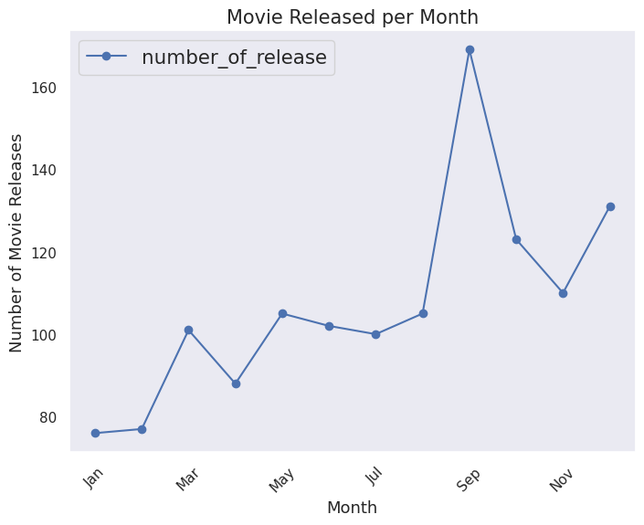

```python
# Use this, and more code cells, to explore your data. Don't forget to add
#   Markdown cells to document your observations and findings.

# Convert the 'release_date' column to datetime objects
df['release_date'] = pd.to_datetime(df['release_date'])

# Count the number of movie releases for each month
number_of_release = df['release_date'].dt.month.value_counts().sort_index()
# Create a list of month names
months = ['Jan', 'Feb', 'Mar', 'Apr', 'May', 'Jun', 'Jul', 'Aug', 'Sep', 'Oct', 'Nov', 'Dec']
# Convert the Series to a DataFrame and reset the index
number_of_release = pd.DataFrame(number_of_release).reset_index()
# Rename the columns
number_of_release.columns = ['month_number', 'number_of_release']
# Add a column for the month names
number_of_release['month'] = months

# Create a line plot of the number of movie releases per month
number_of_release.plot(x='month', y='number_of_release', kind='line', marker='o', fontsize=11, figsize=(8, 6))
# Set the plot title
mpl.title('Movie Released per Month', fontsize=15)
# Set the x-axis label
mpl.xlabel('Month', fontsize=13)
# Set the y-axis label
mpl.ylabel('Number of Movie Releases', fontsize=13)
# Display the plot
mpl.xticks(rotation=45)
mpl.grid()
mpl.show()
```

> From this line chart, we can see that September has the most releases when compared with all the months.

### Question 2: Which actors have the most appearances in movies?

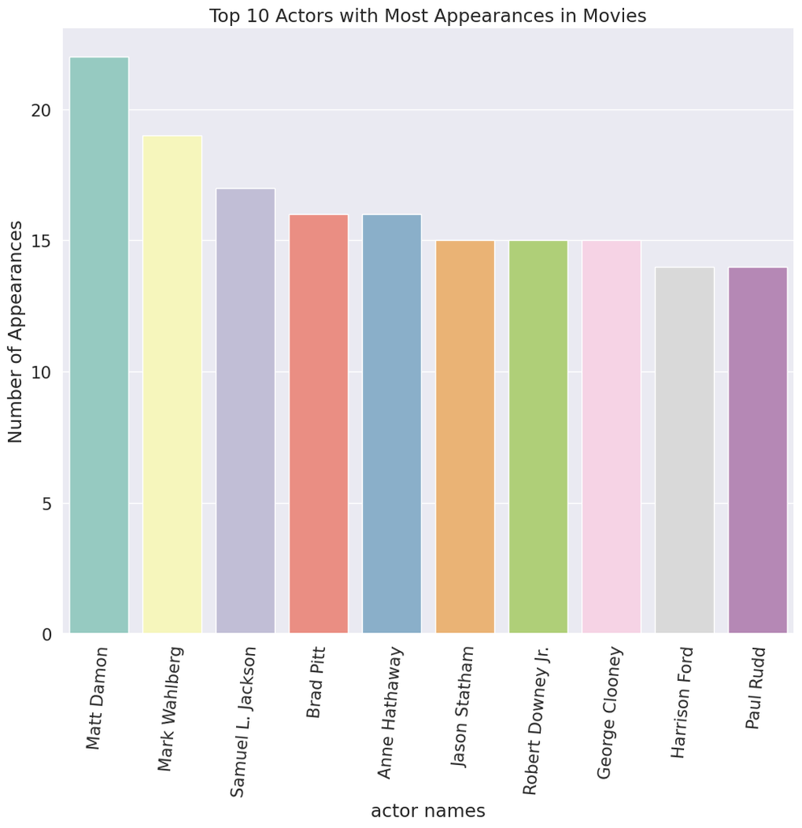

```python
# Continue to explore the data to address your additional research
#   questions. Add more headers as needed if you have more questions to
#   investigate.


# Initialize a dictionary to count actor appearances
actor_dict = {}
actors = df["cast"]
actors = actors.str.split("|")
actors = np.array(actors)

# Count appearances of each actor
for actorList in actors:
    for actor in actorList:
        actor = actor.lstrip()
        if actor not in actor_dict:
            actor_dict[actor] = 1
        else:
            actor_dict[actor] += 1

# Sort the actor dictionary by number of appearances
sorted_actor_dict = sorted(actor_dict.items(), key = operator.itemgetter(1), reverse = True)

# Prepare data for visualization
x_axis = list()
y_axis = list()
for item in sorted_actor_dict[0:10]:
    x_axis.append(item[0])
    y_axis.append(item[1])


# Set up the visualization
sb.set(rc={'figure.figsize': (12, 10)}, font_scale=1.4)
x = sb.barplot(x=x_axis, y=y_axis, palette="Set3")

# Rotate x-axis labels for better readability
for item in x.get_xticklabels():
    item.set_rotation(85)

#Set labels and title
x.set(xlabel='actor names', ylabel='Number of Appearances', title='Top 10 Actors with Most Appearances in Movies')
# Show the plot
mpl.show()
```

> We can see that the top ten actors include A-list celebrities like Samuel L. Jackson, Brad Pitt, Matt Damon, and Harrison Ford. It makes sense that these household names would be found in a large number of movies.